# Midterm Exam #1 (20232) Hands On Session Solutions

**FIZ228 - Numerical Analysis**  
Dr. Emre S. Tasci, Hacettepe University

19/04/2024

```python
import numpy as np
import scipy.optimize as opt
import pandas as pd
import matplotlib.pyplot as plt
```

# 1

Import the given `FIZ228_20232_MT1_data.csv` file as a pandas dataframe.

This data is known to contain signals taken from two joint sinusoidal signal generators (where superposition applies, i.e., $y = y_1 + y_2$).

Rename the first column as "t" and the second as "y"

```python
data = pd.read_csv("../data/FIZ228_20232_MT1_data.csv",header=None)
data.columns = ["t","y"]
data
```

|  | t | y |
| --- | --- | --- |
| 0 | 0.000000 | -0.631523 |
| 1 | 0.033445 | -0.447049 |
| 2 | 0.066890 | -0.331072 |
| 3 | 0.100334 | -0.114149 |
| 4 | 0.133779 | -0.168711 |
| ... | ... | ... |
| 295 | 9.866221 | -1.248320 |
| 296 | 9.899666 | -0.943883 |
| 297 | 9.933110 | -1.443523 |
| 298 | 9.966555 | -1.640351 |
| 299 | 10.000000 | -1.792804 |

300 rows × 2 columns

# 2

Plot its graph as using red dots (no lines).

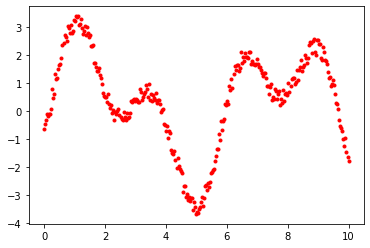

```python
plt.plot(data["t"],data["y"],"r.")
plt.show()
```

# 3

As mentioned above, this data consists of the superposition of two sinusoidal signals, such that:

$$y = A_1\sin(\omega_1 t + \varphi_1)+A_2\sin(\omega_2 t + \varphi_2)$$

Determine the parameters (amplitude, angular frequency and phase) of these two sinusoidal signals that best match to the data given.

(Hint: Depending on your method, you can relax the default tolerance, in other words, don't get upset if a very high precision match can't be obtained)

```python
def f(t,params):
    (A1,A2,w1,w2,ph1,ph2) = params
    return A1*np.sin(w1*t+np.deg2rad(ph1)) + \
           A2*np.sin(w2*t+np.deg2rad(ph2))
```

```python
def err_f(params):
    return ((data["y"] - f(data["t"],params))**2).sum()
```

```python
res = opt.minimize(err_f,[3,2,2,1,0,-1])
res
```

```
      fun: 9.212506361972885
 hess_inv: array([[ 3.57003922e-03,  2.25792574e-04,  2.82854645e-05,
         1.33087083e-04, -1.45580153e-02, -3.44404868e-02],
       [ 2.25792574e-04,  4.49656576e-03, -1.38716170e-04,
        -4.40773031e-05,  7.99209961e-03,  2.34885404e-02],
       [ 2.82854645e-05, -1.38716170e-04,  6.20287290e-05,
         2.78434072e-05, -4.56936653e-03, -1.11882206e-02],
       [ 1.33087083e-04, -4.40773031e-05,  2.78434072e-05,
         8.61266226e-05, -9.93953936e-03, -2.47799129e-02],
       [-1.45580153e-02,  7.99209961e-03, -4.56936653e-03,
        -9.93953936e-03,  1.60636606e+00,  3.89858320e+00],
       [-3.44404868e-02,  2.34885404e-02, -1.11882206e-02,
        -2.47799129e-02,  3.89858320e+00,  9.74387856e+00]])
      jac: array([-4.76837158e-07, -3.09944153e-06,  2.24113464e-05,  1.39474869e-05,
        3.57627869e-07, -2.38418579e-07])
  message: 'Desired error not necessarily achieved due to precision loss.'
     nfev: 371
      nit: 27
     njev: 53
   status: 2
  success: False
        x: array([  1.50023154,   2.01452057,   2.30302471,   0.99961517,
       -35.64788195,  -0.05551862])
```

# 4

Using these parameters, construct your estimation function and introduce a third column labeled "e" on your dataframe that holds the function values with respect to your t values.

```python
data["e"] = f(data["t"],res.x)
```

```python
data
```

|  | t | y | e |
| --- | --- | --- | --- |
| 0 | 0.000000 | -0.631523 | -0.876290 |
| 1 | 0.033445 | -0.447049 | -0.712552 |
| 2 | 0.066890 | -0.331072 | -0.544274 |
| 3 | 0.100334 | -0.114149 | -0.372130 |
| 4 | 0.133779 | -0.168711 | -0.196818 |
| ... | ... | ... | ... |
| 295 | 9.866221 | -1.248320 | -1.014949 |
| 296 | 9.899666 | -0.943883 | -1.189764 |
| 297 | 9.933110 | -1.443523 | -1.361917 |
| 298 | 9.966555 | -1.640351 | -1.530671 |
| 299 | 10.000000 | -1.792804 | -1.695307 |

300 rows × 3 columns

# 5

Plot the given data against the model estimation (data points: red dots as above; model estimation: dashed line)

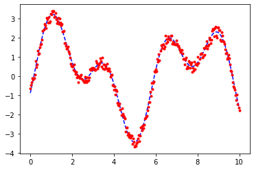

```python
plt.plot(data["t"],data["e"],"b--")
plt.plot(data["t"],data["y"],"r.")
plt.show()
```

# 6

Calculate the following error estimations between the given data and your model:$\DeclareMathOperator\erf{erf}$

- $\erf_1 = \sqrt{\sum_{i}{(y_i - e_i)^2}}$
- $\erf_2 = \sum_{i}{|y_i - e_i|}$

  where $y$ indicates the given data and $e$ the model estimation.

  Also calculate the coefficient of determination ($r^2$).

```python
erf1 = np.sqrt(((data["y"] - data["e"])**2).sum())
erf2 = np.abs((data["y"] - data["e"]).sum())
erf1,erf2
```

```
(3.0352110901834957, 3.886792829550611)
```

```python
S_r = ((data["y"] - data["e"])**2).sum()
S_t = ((data["y"] - data["y"].mean())**2).sum()
r2 = (S_t - S_r) / S_t

r2
```

```
0.9890390943345185
```

# 7

The data presented was obtained by adding noise to the data calculated with the following parameters:

$$\begin{align*}A_1 &= 2.0& \omega_1 &= 1.0& \varphi_1 &=0.0\\ A_2 &= 1.5& \omega_2 &= 2.3& \varphi_2 &=-35.0^o \end{align*}$$

*(You can't use these values to spot a good starting position for the above operations!)*

Plot the data along with your fit and the model constructed with these parameters like you did in part 5.

Calculate the error estimations between the data and a model constructed with these parameters like you did in part 6.

```python
params_org = [2.0,1.5,1.0,2.3,0.0,-35.0]
y_org = f(data["t"],params_org)
```

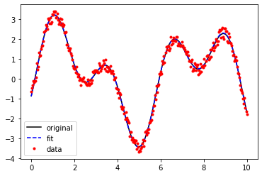

```python
plt.plot(data["t"],y_org,"k-")
plt.plot(data["t"],data["e"],"b--")
plt.plot(data["t"],data["y"],"r.")
plt.legend(["original","fit","data"])
plt.show()
```

```python
erf1o = np.sqrt(((data["y"] - y_org)**2).sum())
erf2o = np.abs((data["y"] - y_org).sum())
erf1o,erf2o
```

```
(3.0482001175866738, 3.222162372189898)
```

```python
S_ro = ((data["y"] - y_org)**2).sum()
S_to = ((data["y"] - data["y"].mean())**2).sum()
r2o = (S_to - S_ro) / S_to

r2o
```

```
0.9889450803529385
```